# Project Python Foundations: FoodHub Data Analysis

### **Question 7**: Which are the top 5 restaurants in terms of the number of orders received? [1 mark]

```python
# count values with value_counts() function
df['restaurant_name'].value_counts()
```

```
Shake Shack                  219
The Meatball Shop            132
Blue Ribbon Sushi            119
Blue Ribbon Fried Chicken     96
Parm                          68
                            ...
Sushi Choshi                   1
Dos Caminos Soho               1
La Follia                      1
Philippe Chow                  1
'wichcraft                     1
Name: restaurant_name, Length: 178, dtype: int64
```

#### Observations:

Shake shack, The Meatball Shop, Blue Ribbon Sushi, Blue Ribbon Fried Chicken, and Parm received the most orders.

### **Question 8**: Which is the most popular cuisine on weekends? [1 mark]

```python
# groupby day_of_the_week and then use the value_counts function to generate a count
df.groupby('day_of_the_week')['cuisine_type'].value_counts()
```

```
day_of_the_week  cuisine_type
Weekday          American          169
                 Japanese          135
                 Italian            91
                 Chinese            52
                 Indian             24
                 Mexican            24
                 Middle Eastern     17
                 Mediterranean      14
                 Southern            6
                 French              5
                 Thai                4
                 Vietnamese          3
                 Korean              2
                 Spanish             1
Weekend          American          415
                 Japanese          335
                 Italian           207
                 Chinese           163
                 Mexican            53
                 Indian             49
                 Mediterranean      32
                 Middle Eastern     32
                 Thai               15
                 French             13
                 Korean             11
                 Southern           11
                 Spanish            11
                 Vietnamese          4
Name: cuisine_type, dtype: int64
```

#### Observations:

American cuisine is the most popular on the weekends.

### **Question 9**: What percentage of the orders cost more than 20 dollars? [2 marks]

```python
# Filter the cost of the order and then count the values
df.loc[df['cost_of_the_order']>20]['cost_of_the_order'].value_counts()
```

```
24.20    42
29.10    37
24.25    36
24.30    35
29.15    30
         ..
35.41     1
21.20     1
33.22     1
29.83     1
29.59     1
Name: cost_of_the_order, Length: 73, dtype: int64
```

```python
#Length divided by number of rows, multiplied by 100 to get the percentage
(73/df.shape[0])*100
```

```
3.8461538461538463
```

### **Question 10**: What is the mean order delivery time? [1 mark]

```python
# Use the mean function
df['delivery_time'].mean()
```

```
24.161749209694417
```

#### Observations:

The average delivery time is 24.16

### **Question 11:** The company has decided to give 20% discount vouchers to the top 3 most frequent customers. Find the IDs of these customers and the number of orders they placed. [1 mark]

```python
# Write the code here
df['customer_id'].value_counts()
```

```
52832     13
47440     10
83287      9
250494     8
259341     7
          ..
385426     1
254913     1
289597     1
74412      1
397537     1
Name: customer_id, Length: 1200, dtype: int64
```

#### Observations:

Customer 52832 placed 13 orders, Customer 47440 placed 10 orders, and Customer 83287 placed 9 orders.

### **Question 12**: Perform a multivariate analysis to explore relationships between the important variables in the dataset. (It is a good idea to explore relations between numerical variables as well as relations between numerical and categorical variables) [10 marks]

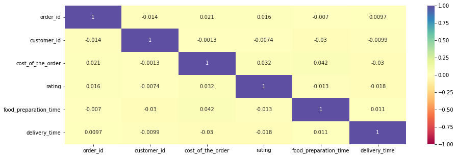

```python
# Let's start with a heat map to look at the correlations between numerical variables.
plt.figure(figsize=(15,5))
sns.heatmap(df.corr(),annot=True,cmap='Spectral',vmin=-1,vmax=1)
plt.show()
```

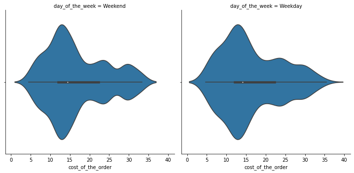

```python
# Let's see if the distribution of the cost of the order varies significantly according to the day of the week.
sns.catplot(x='cost_of_the_order',
            col='day_of_the_week',
            data=data,
            col_wrap=4,
            kind="violin")
plt.show()
```

..... looks like it doesn't.

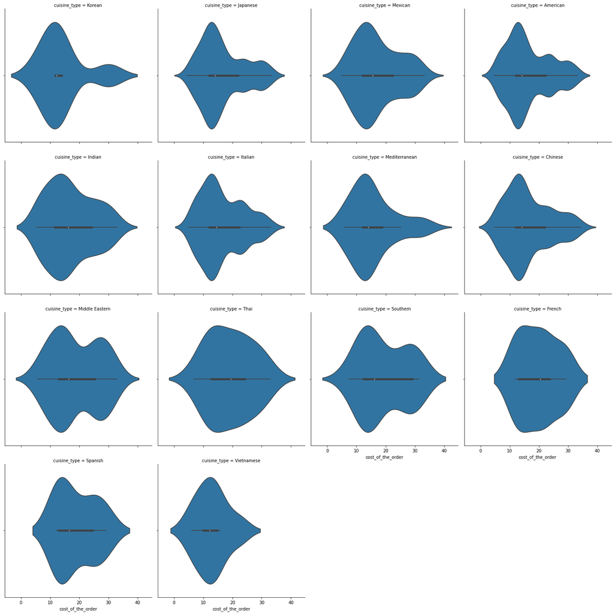

```python
# Let's do the same but with respect to cuisine type.
sns.catplot(x='cost_of_the_order',
            col='cuisine_type',
            data=data,
            col_wrap=4,
            kind="violin")
plt.show()
```

At first glance it looks like French and Thai orders are on average a bit more expensive than the other types of cuisines, seeing as the distribution is barely skewed on either side and the mean order is close to 20$.

```python
# Lastly, let's see which cuisine types are most highly rated by users
df.groupby('cuisine_type')['rating'].mean()
```

```
cuisine_type
American          4.284111
Chinese           4.384977
French            4.333333
Indian            4.643836
Italian           4.420775
Japanese          4.376333
Korean            4.136364
Mediterranean     4.347826
Mexican           4.447368
Middle Eastern    4.204082
Southern          4.235294
Spanish           4.916667
Thai              4.714286
Vietnamese        4.142857
Name: rating, dtype: float64
```

It appears Spanish, Thai, and Indian food receive the highest ratings.

### **Question 13:** The company wants to provide a promotional offer in the advertisement of the restaurants. The condition to get the offer is that the restaurants must have a rating count of more than 50 and the average rating should be greater than 4. Find the restaurants fulfilling the criteria to get the promotional offer. [3 marks]

```python
# First find the count of all orders per restaurant name
df2=df['restaurant_name'].value_counts()
df2
```

```
Shake Shack                  219
The Meatball Shop            132
Blue Ribbon Sushi            119
Blue Ribbon Fried Chicken     96
Parm                          68
                            ...
Sushi Choshi                   1
Dos Caminos Soho               1
La Follia                      1
Philippe Chow                  1
'wichcraft                     1
Name: restaurant_name, Length: 178, dtype: int64
```

```python
#find the mean, and filter by restaurants that received more than 50 orders.
df.groupby('restaurant_name')['rating'].mean().loc[df2>50]
```

```
restaurant_name
Blue Ribbon Fried Chicken    4.385417
Blue Ribbon Sushi            4.134454
Parm                         4.073529
RedFarm Broadway             4.169492
RedFarm Hudson               4.109091
Shake Shack                  4.168950
The Meatball Shop            4.689394
Name: rating, dtype: float64
```

### **Question 14:** The company charges the restaurant 25% on the orders having cost greater than 20 dollars and 15% on the orders having cost greater than 5 dollars. Find the net revenue generated by the company across all orders. [3 marks]

```python
# Write a function calculate revenue and apply it to the revenue series
def calculateRevenue(s):
    r=s
    if s>5 and s<20:
        r=s*.15
    if s>20:
        r=s*.25
    return r

df['revenue']=df['cost_of_the_order'].apply(calculateRevenue)
df.tail()
#dropping a column that I unneccessarily created while trying to figure out the previous problem
df.drop(['rating_counts'],axis=1,inplace=True)
```

### **Question 15:** The company wants to analyze the total time required to deliver the food. What percentage of orders take more than 60 minutes to get delivered from the time the order is placed? (The food has to be prepared and then delivered.) [2 marks]

```python
# create a new row in the data frame consisting of the sum of the food preparation time and the food delivery time
# filter the new dataframe for orders that take more than 60 mins
df['total_time']=df['food_preparation_time']+df['delivery_time']
df.loc[df['total_time']>60]
```

|  | order_id | customer_id | restaurant_name | cuisine_type | cost_of_the_order | day_of_the_week | rating | food_preparation_time | delivery_time | revenue | total_time |
| --- | --- | --- | --- | --- | --- | --- | --- | --- | --- | --- | --- |
| 7 | 1477859 | 89574 | Barbounia | Mediterranean | 5.97 | Weekday | 3.0 | 33 | 30 | 0.8955 | 63 |
| 10 | 1477895 | 143926 | Big Wong Restaurant _¤¾Ñ¼ | Chinese | 5.92 | Weekday | NaN | 34 | 28 | 0.8880 | 62 |
| 19 | 1477354 | 67487 | Blue Ribbon Sushi | Japanese | 16.20 | Weekend | 4.0 | 35 | 26 | 2.4300 | 61 |
| 24 | 1476714 | 363783 | Cafe Mogador | Middle Eastern | 15.86 | Weekday | 4.0 | 32 | 29 | 2.3790 | 61 |
| 54 | 1477760 | 130507 | Jack's Wife Freda | Mediterranean | 22.75 | Weekend | 3.0 | 35 | 29 | 5.6875 | 64 |
| ... | ... | ... | ... | ... | ... | ... | ... | ... | ... | ... | ... |
| 1869 | 1476923 | 50199 | J. G. Melon | American | 19.40 | Weekday | 4.0 | 35 | 26 | 2.9100 | 61 |
| 1873 | 1478148 | 261371 | Shake Shack | American | 22.31 | Weekend | 4.0 | 35 | 28 | 5.5775 | 63 |
| 1875 | 1478039 | 292343 | Amy Ruth's | Southern | 12.23 | Weekday | 4.0 | 32 | 33 | 1.8345 | 65 |
| 1880 | 1477466 | 222734 | Shake Shack | American | 13.97 | Weekend | 5.0 | 35 | 27 | 2.0955 | 62 |
| 1889 | 1478190 | 94152 | RedFarm Broadway | Chinese | 8.68 | Weekday | 3.0 | 33 | 30 | 1.3020 | 63 |

200 rows × 11 columns

```python
percentage=200/df.shape[0]*100
print(percentage)
```

```
10.537407797681771
```

#### Observations:

10.54% of all orders require a total time of over 60 minutes to be prepared and delivered.

### **Question 16:** The company wants to analyze the delivery time of the orders on weekdays and weekends. How does the mean delivery time vary during weekdays and weekends? [2 marks]

```python
# Group by day of the week and then mean delivery time
df.groupby('day_of_the_week')['delivery_time'].mean()
```

```
day_of_the_week
Weekday    28.340037
Weekend    22.470022
Name: delivery_time, dtype: float64
```

```python
difference=28.340037-22.470022
print(difference)
```

```
5.870014999999999
```

#### Observations:

The mean delivery time on weekdays in 5.87 minutes longer than on the weekends.

### Conclusion and Recommendations

### **Question 17:** What are your conclusions from the analysis? What recommendations would you like to share to help improve the business? (You can use cuisine type and feedback ratings to drive your business recommendations.) [6 marks]

### Conclusions:

- App traffic is much higher on the weekends than on the weekdays (70% vs 30%). It seems that users view the app as more of a weekend guilty pleasure option rather than something they can use any day of the week.
- Spanish, Indian, and Thai food receive the highest ratings.
- Not that many customers order from the app more than once.
- The average rating is decently high, and there are no ratings below 3 stars (pretty impressive).

### Recommendations:

- Offer an incentive to order on the weekdays to increase traffic.
- If a restaurant is new and falls under the category of Spanish, Indian, or Thai, expedite the onboarding.
- Prioritize the Spanish, Indian, and Thai restaurants on the display.
- Offer some kind of incentive for repeat customers so that they'll come back. Maybe consider push notification if they haven't logged on the app in a while?